# Домашнее задание №1

Бабикова Евгения

17 10 2017

## Работа с данными

В `data.df` содержится 5070 объектов и 27 переменных.

Имена колонок:

```
## V1 V2 V3 V4 V5 V6 V7 V8 V9 V10 V11 V12 V13 V14 V15 V16 V17 V18 V19 V20 V21 V22 V23 V24 V25 V26 V27
```

Значение ячейки 5-ой строки 7-го столбца:

```
## 0
```

Вторая строка:

```
##   V1 V2 V3 V4 V5 V6 V7 V8 V9 V10 V11 V12 V13 V14 V15 V16 V17 V18 V19 V20
## 2 60  4  2  0  0  0  0  0  0   0   0   0   0   0   0   0   0   0   0   0
##   V21 V22 V23 V24 V25 V26 V27
## 2   0   0   0   0   0   0   0
```

Команда `names(data.df) <- c("year", "month", "day", seq(0,23))` присваивает имена колонкам.

Просмотр таблицы с помощью команды `head()`

```
##   year month day 0 1 2 3 4 5 6 7 8 9 10 11 12 13 14 15 16 17 18 19 20 21
## 1   60     4   1 0 0 0 0 0 0 0 0 0 0  0  0  0  0  0  0  0  0  0  0  0  0
## 2   60     4   2 0 0 0 0 0 0 0 0 0 0  0  0  0  0  0  0  0  0  0  0  0  0
## 3   60     4   3 0 0 0 0 0 0 0 0 0 0  0  0  0  0  0  0  0  0  0  0  0  0
## 4   60     4   4 0 0 0 0 0 0 0 0 0 0  0  0  0  0  0  0  0  0  0  0  0  0
## 5   60     4   5 0 0 0 0 0 0 0 0 0 0  0  0  0  0  0  0  0  0  0  0  0  0
## 6   60     4   6 0 0 0 0 0 0 0 0 0 0  0  0  0  0  0  0  0  0  0  0  0  0
##   22 23
## 1  0  0
## 2  0  0
## 3  0  0
## 4  0  0
## 5  0  0
## 6  0  0
```

и `tail()`

```
##      year month day 0 1 2 3 4 5 6 7 8 9 10 11 12 13 14 15 16 17 18 19 20
## 5065   80    11  25 0 0 0 0 0 0 0 0 0 0  0  0  0  0  0  0  0  0  0  0  0
## 5066   80    11  26 0 0 0 0 0 0 0 0 0 0  0  0  0  0  0  0  0  0  0  0  0
## 5067   80    11  27 0 0 0 0 0 0 0 0 0 0  0  0  0  0  0  0  0  0  0  0  0
## 5068   80    11  28 0 0 0 0 0 0 0 0 0 0  0  0  0  0  0  0  0  0  0  0  0
## 5069   80    11  29 0 0 0 0 0 0 0 0 0 0  0  0  0  0  0  0  0  0  0  0  0
## 5070   80    11  30 0 0 0 0 0 0 0 0 0 0  0  0  0  0  0  0  0  0  0  0  0
##      21 22 23
## 5065  0  0  0
## 5066  0  0  0
## 5067  0  0  0
## 5068  0  0  0
## 5069  0  0  0
## 5070  0  0  0
```

Последние 24 колонки - количество осадков за час.

Гистограмма колонки `daily` - сумма крайних 24-х столбцов.

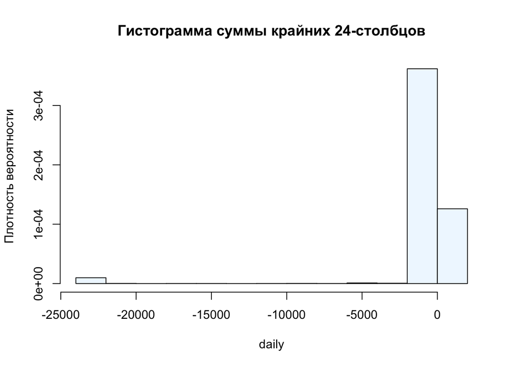

Полученная гистограмма не позволяет сделать выводы по данным, так как строится неверно. Чтобы исправить это, необходимо находить модуль суммы столбцов, содержащих количество осадков по часам. Результат этого добавлен к датафрейму `fixed.daily`.

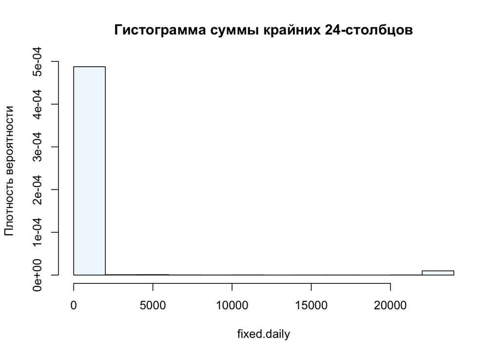

## Синтаксис и типизирование

Вектор v:

```
## 4 8 15 16 23 42
## Максимальное значение: 8
## Вектор по возрастанию: 15 16 23 4 42 8
```

Команда `max()` для вектора `v` возвращает второй элемент данного вектора, так как он имеет наибольший код символа (ASCII). По такому же признакому работает команда `sort()`. Сумму для `v` посчитать невозможно, так как данная операция производится только с числовыми или логическими значениями.

Сумму `v2[2] + v2[3]` посчитать нельзя, так как вектор `v2` состоит из элементов типа `char`.

Датафрейм `df3`:

```
##   z1 z2 z3
## 1  5  7 12
```

```
## df3[1,2] + df3[1,3] = 19
```

Сумму `df3[1,2] + df3[1,3]` посчитать можно. В датафрейме каждый столбец - вектор, содержащий данные определенного типа, которые могут не совпадать. В данном случае `df3` состоит из числовых и категориального данных.

Список `l4`:

```
## $z1
## [1] "6"
##
## $z2
## [1] 42
##
## $z3
## [1] "49"
##
## $z4
## [1] 126
```

```
##
## l4[[2]] + l4[[4]] = 168
```

Сумму `l4[[2]] + l4[[4]]` посчитать можно. Список может содержат объекты разных типов (здесь целые числа и символы). Операции с элементами списка возможны только через `[[]]`. Поэтому невозможно выполнить команду `l4[2] + l4[4]`.

## Работа с функциями и операторами

Числа от 1 до 10000 с инкрементом 372:

```
## 1 373 745 1117 1489 1861 2233 2605 2977 3349 3721 4093 4465 4837 5209 5581 5953 6325 6697 7069 7441 7813 8185 8557 8929 9301 9673
```

Числа от 1 до 10000 длиной 50:

[output not shown]

Повтор чисел от 1 до 5 три раза (`times`):

```
## 1 2 3 4 5 1 2 3 4 5 1 2 3 4 5
```

Повтор каждого числа из последовательности от 1 до 5 по три раза (`each`):

```
## 1 1 1 2 2 2 3 3 3 4 4 4 5 5 5
```